# R markdown file for “BitPhylogeny: A probabilistic framework for reconstructing intra-tumor phylogenies”

# 1 The `BitPhylogeny` package

## 1.1 Installation

The `BitPhylogeny` package depends on several `python` and `R` packages. The first step is to make sure the following the packages are installed. * `python`: numpy, scipy, scikit-learn: http://scikit-learn.org/stable/, rpy2: http://rpy.sourceforge.net/, pandas: http://pandas.pydata.org/, h5py: http://www.h5py.org/, igraph. * `R`: rPython, mcclust, e1071, igraph, gplots, riverplot, plyr.

Secondly, clone the BitPhylogeny repository

```
git clone git@bitbucket.org:ke_yuan/bitphylogeny.git
cd bitphylogeny
```

The third step is install the BitPhylogeny python package. To do this, navigate into the python directory and run the following

```
cd python
sudo python setup.py install
```

Finally, install the R package

```
cd ../R
R CMD INSTALL bitphylogenyR_0.99.tar.gz
```

## 1.2 An example

### 1.2.1 BitPhylogeny

We use an example dataset

```r
library('bitphylogenyR')
example_file <- system.file('sample_data.csv', package='bitphylogenyR')
tmp <- read.csv( example_file )
head(tmp)
```

```
##   V1 V2 V3 V4 V5 V6 V7 V8 V9
## 1  0  0  0  0  0  0  0  0  1
## 2  0  0  0  0  0  0  0  0  1
## 3  0  0  0  0  0  0  0  0  1
## 4  0  0  0  0  0  0  0  0  1
## 5  0  0  0  0  0  0  0  0  1
## 6  0  0  0  0  0  0  0  0  1
```

Note that the last column is set to be the true cluster label of each data point. We separate the data and its label.

```r
x <- tmp[,-dim(tmp)[2]]
true_label <- tmp[,dim(tmp)[2]]
```

Run the BitPhylogeny analysis as the following

```r
bitphyloR(example_file, './output', T, 200, 50, 5)
```

By default, `bitphyloR` runs with methylation model setting. To analyse mutation data, one can use the `mode` parameter

```r
bitphyloR(example_file, './output', T, 200, 50, 5, mode = "mutation")
```

The program saves the results in the directory ‘output’.

```r
dir('./output', recursive=T)
```

```
##  [1] "sample_data.csv/mcmc-traces/branch_traces.csv"
##  [2] "sample_data.csv/mcmc-traces/label_traces.csv"
##  [3] "sample_data.csv/mcmc-traces/mpear_label.csv"
##  [4] "sample_data.csv/mcmc-traces/mpear_vmeasure.csv"
##  [5] "sample_data.csv/mcmc-traces/node_depth_traces.csv"
##  [6] "sample_data.csv/mcmc-traces/other_traces.csv"
##  [7] "sample_data.csv/mcmc-traces/params_traces.h5"
##  [8] "sample_data.csv/mcmc-traces/root_param_traces.csv"
##  [9] "sample_data.csv/mcmc-traces/vmeasure_traces.csv"
## [10] "sample_data.csv/treescripts/nodes-3.graphml"
## [11] "sample_data.csv/treescripts/nodes-4.graphml"
## [12] "sample_data.csv/treescripts/nodes-5.graphml"
## [13] "sample_data.csv/treescripts/nodes-6.graphml"
## [14] "sample_data.csv/treescripts/tree-freq.csv"
```

The clustering performance is assessed by the V-measure. In addition, the label trace is summarised by the maximum posterior expected adjusted Rand method.

```r
compute_vmeasures('./output/sample_data.csv',
                  system.file('sample_data.csv', package='bitphylogenyR'))
```

We can visualise the results in the following way

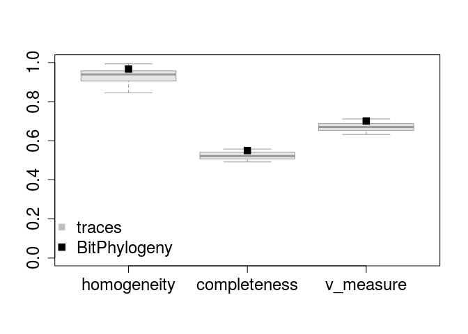

```r
fp <- get_path('./output/sample_data.csv', 'mcmc-traces')
vmeasure_traces <- as.matrix(load_vmeasures(fp, 'vmeasure_traces.csv'))
mpear_vmeasure <- as.matrix(load_vmeasures(fp, 'mpear_vmeasure.csv'))
class(vmeasure_traces) <- 'numeric'
class(mpear_vmeasure) <- 'numeric'
par(cex.lab=1.5, cex.axis=1.5)
boxplot(vmeasure_traces, outline=F, cex.main=1.3, ylim=c(0,1),
        border=c('gray60'), col='gray90')
points(c(1,2,3),mpear_vmeasure, pch=22,cex = 1.5, bg= 'black')
colors1 <- c("gray90",'black')
colors2 <- c("gray",'black')
add_legend("bottomleft", legend=c("traces", 'BitPhylogeny'),
           pch=c(22,22), inset = c(0.1,0.20), col=colors1,
           pt.bg=colors2,
           horiz=F, bty='n', cex=1.5)
```

The resulting trees are stored in the `treescripts` directory. The file `tree-freq` contains the appearance frequency of each tree in the folder.

```r
treefreq <- read.csv('./output/sample_data.csv/treescripts//tree-freq.csv')
treefreq
```

```
##   unique_node_num  freq
## 1               3 0.325
## 2               4 0.550
## 3               5 0.100
## 4               6 0.025
```

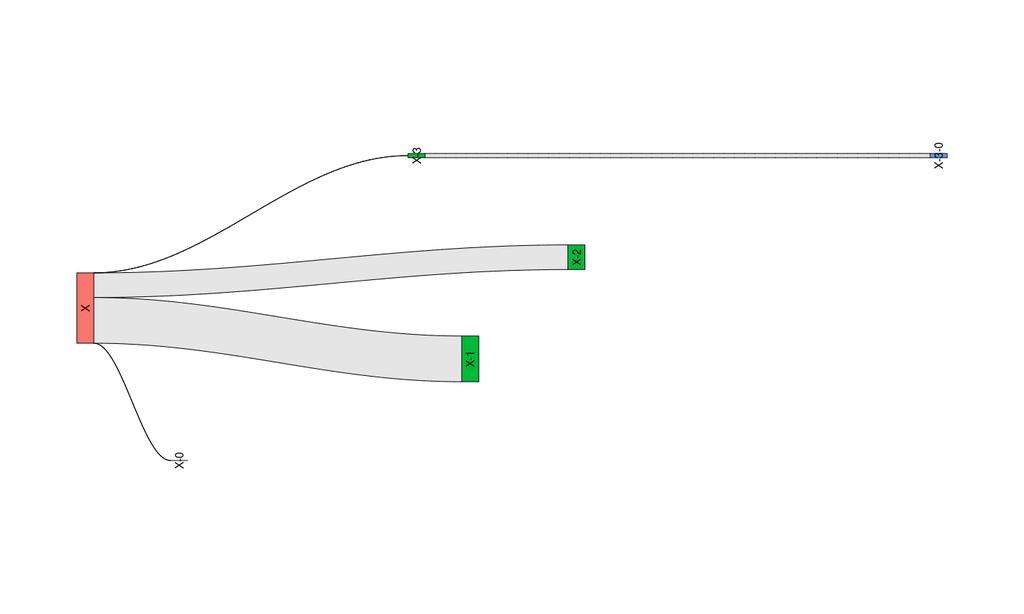

```r
plot_sankey_mft('./output/sample_data.csv/treescripts//tree-freq.csv')
```

Alternatively, the .gdl files can be visualised with the [aisee3](http://www.absint.com/aisee/index.htm) software.

### 1.2.2 Baseline methods

The baseline methods are consisted of clustering followed by minimum spanning tree construction.

#### 1.2.2.1 Hierarchical clustering

We first compute the Jacard distance matrix for the sequences.

```r
dis <- dist(x, 'binary')
```

Then, we use the R function `hclust` to perform hierarchical clustering based on the previously computed distance matrix.

```r
hc <- hclust(dis)
hc
```

```
##
## Call:
## hclust(d = dis)
##
## Cluster method   : complete
## Distance         : binary
## Number of objects: 200
```

The resulting labels of each data point is obtained with the function `cutree`. The function takes the output of `hclust` and the number of desired clusters `k`. In this case, we set `k` to be $7$.

```r
label <- cutree(hc, k=7)
label
```

```
##   [1] 1 1 1 1 1 1 1 1 1 1 1 1 1 1 1 1 1 1 1 1 1 1 1 1 1 1 1 2 1 1 1 1 1 1 1
##  [36] 1 1 1 3 1 1 1 1 1 1 1 1 3 1 1 1 1 1 1 1 1 1 1 1 1 1 1 1 1 1 4 4 4 4 4
##  [71] 4 4 4 4 4 4 4 4 4 4 4 4 4 4 4 4 4 4 4 5 4 4 4 4 4 4 4 4 4 6 4 4 4 4 4
## [106] 6 4 4 4 4 4 4 4 6 4 4 4 4 4 5 4 4 4 4 4 4 4 4 4 4 4 4 4 4 4 4 4 4 4 4
## [141] 4 4 4 4 4 4 4 4 4 4 4 4 7 4 4 4 4 4 5 5 5 5 5 5 5 5 5 5 5 5 5 5 7 7 7
## [176] 7 7 7 6 6 6 6 6 5 5 5 5 5 7 7 7 7 7 7 4 4 7 7 7 7
```

When there is a range of cluster number hypothesis, we compute a list of possible labels.

```r
K <- seq(2,14,1)
hc_cand <- lapply(K, function(ii) cutree(hc, ii) )
```

Each of these hypothesis is evaluated by the Silhouette score. The one with the highest score is chosen as the clustering result.

```r
library(cluster)
hc_silhouette_res <- sapply(1:length(K),
                              function(ii)
                                summary( silhouette(hc_cand[[ii]] ,dis) )$avg.width )
idx <- which.max( hc_silhouette_res )
hc_label <- hc_cand[[idx]]
hc_label
```

```
##   [1]  1  1  1  1  1  1  1  1  1  1  1  1  1  1  1  1  1  1  1  1  1  1  1
##  [24]  1  1  1  1  2  1  1  1  1  1  1  1  1  1  1  3  1  1  1  1  1  1  1
##  [47]  1  3  1  1  1  1  1  1  1  1  1  1  1  1  1  1  1  1  1  4  4  4  5
##  [70]  4  4  4  4  4  4  4  4  4  4  4  4  4  4  4  6  6  6  6  6  7  6  6
##  [93]  6  6  6  6  6  6  6  8  6  6  6  6  6  8  6  6  6  6  6  6  6  9  6
## [116]  6  6  6  6 10  6  6  6  6  6  6  6  4  4  4  4  4  4  4  4  5  5  5
## [139]  5  5  5  5  5  5  5  5  5  5  5  5  5  5 11  5  5  5  5  5  7  7  7
## [162]  7  7  7  7 12  7  7  7  7  7  7 11 11 11 11 11 11  9  9  9  9  9 13
## [185] 13 13 13 13 14 14 14 14 14 14  4  5 11 11 11 14
```

Once the label is computed, we compute the genotype of each cluster as the following

```r
clone <- sapply(unique(hc_label), function(i) which(hc_label==i) )
n <- length(clone)
hc_genotype <- matrix(0, n, dim(x)[2])
for (i in 1:n){
    idx <- clone[[i]]
    if ( length(idx)==1 ){
      hc_genotype[i,] <- as.matrix(x[idx,])
    }else{
      hc_genotype[i,] <- as.numeric( colMeans(as.matrix(x[idx,])) > 0.5 )
    }
}
hc_genotype
```

```
##       [,1] [,2] [,3] [,4] [,5] [,6] [,7] [,8]
##  [1,]    0    0    0    0    0    0    0    0
##  [2,]    0    0    0    0    1    0    0    0
##  [3,]    0    1    0    0    0    0    0    0
##  [4,]    0    0    0    1    0    0    1    1
##  [5,]    0    1    0    1    0    1    1    1
##  [6,]    0    0    0    1    0    0    0    1
##  [7,]    0    0    0    1    0    1    0    1
##  [8,]    0    0    0    1    0    0    0    0
##  [9,]    1    0    0    1    0    0    0    1
## [10,]    0    0    0    0    0    0    0    1
## [11,]    0    1    0    1    1    1    1    1
## [12,]    0    0    0    0    0    1    0    1
## [13,]    0    0    0    1    1    1    0    1
## [14,]    1    1    1    1    1    1    0    1
```

Finally, we put the above steps into a function which gives the label and genotype estimates.

```r
get_label_hc
```

```
## function (x, K)
## {
##     dis <- dist(x, "binary")
##     hc_cand <- lapply(K, function(ii) cutree(hclust(dis), ii))
##     hc_silhouette_res <- sapply(1:length(K), function(ii) summary(silhouette(hc_cand[[ii]],
##         dis))$avg.width)
##     idx <- which.max(hc_silhouette_res)
##     hc_label <- hc_cand[[idx]]
##     clone <- sapply(unique(hc_label), function(i) which(hc_label ==
##         i))
##     n <- length(clone)
##     genotype <- matrix(0, n, dim(x)[2])
##     for (i in 1:n) {
##         idx <- clone[[i]]
##         if (length(idx) == 1) {
##             genotype[i, ] = as.matrix(x[idx, ])
##         }
##         else {
##             genotype[i, ] = as.numeric(colMeans(as.matrix(x[idx,
##                 ])) > 0.5)
##         }
##     }
##     return(list(label = hc_label, genotype = genotype))
## }
## <environment: namespace:bitphylogenyR>
```

#### 1.2.2.2 K-centroids clustering

The k-centroids methods uses the same distance matrix compute above.

```r
kc = pam(dis, 7)
kc
```

```
## Medoids:
##       ID
## [1,]  65  65
## [2,] 194 194
## [3,] 158 158
## [4,] 195 195
## [5,] 127 127
## [6,] 172 172
## [7,] 135 135
## Clustering vector:
##   [1] 1 1 1 1 1 1 1 1 1 1 1 1 1 1 1 1 1 1 1 1 1 1 1 1 1 1 1 2 1 1 1 1 1 1 1
##  [36] 1 1 1 3 1 1 1 1 1 1 1 1 3 1 1 1 1 1 1 1 1 1 1 1 1 1 1 1 1 1 4 4 4 3 4
##  [71] 4 4 4 4 4 4 4 4 4 4 4 4 4 4 5 5 5 5 5 6 5 5 5 5 5 5 5 5 5 5 5 5 5 5 5
## [106] 5 5 5 5 5 5 5 5 7 5 5 5 5 5 5 5 5 5 5 5 5 5 7 7 7 7 7 7 7 7 3 3 3 3 3
## [141] 3 3 3 3 3 3 3 3 3 3 3 3 3 3 3 3 3 3 3 6 6 6 6 6 6 6 6 6 6 6 6 6 3 3 3
## [176] 3 3 3 7 7 7 7 7 6 6 6 6 6 2 2 2 2 2 2 4 3 2 2 2 2
## Objective function:
##   build    swap
## 0.05225 0.05225
##
## Available components:
## [1] "medoids"    "id.med"     "clustering" "objective"  "isolation"
## [6] "clusinfo"   "silinfo"    "diss"       "call"
```

In this case, the genotypes can be obtained as the metroids. The Silhouette score is used to choose the number of clusters.

```r
kc_cand <- lapply(K, function(ii) pam( dis, ii) )
kc_silhouette_res <- sapply(1:length(K), function(ii)
                            summary( silhouette(kc_cand[[ii]]$clustering,dis) )$avg.width )
idx <- which.max( kc_silhouette_res )

kc_label <- kc_cand[[idx]]$clustering
kc_label
```

```
##   [1]  1  1  1  1  1  1  1  1  1  1  1  1  1  1  1  1  1  1  1  1  1  1  1
##  [24]  1  1  1  1  2  1  1  1  1  1  1  1  1  1  1  3  1  1  1  1  1  1  1
##  [47]  1  3  1  1  1  1  1  1  1  1  1  1  1  1  1  1  1  1  1  4  4  4  5
##  [70]  4  4  4  4  4  4  4  4  4  4  4  4  4  4  4  6  6  6  6  6  7  6  6
##  [93]  6  6  6  6  6  6  6  8  6  6  6  6  6  8  6  6  6  6  6  6  6  9  6
## [116]  6  6  6  6 10  6  6  6  6  6  6  6 11 11 11 11 11 11 11 11  5  5  5
## [139]  5  5  5  5  5  5  5  5  5  5  5  5  5  5 12  5  5  5  5  5  5  7  7
## [162]  7  7  7  7  7  7  7  7  7  7  7 12 12 12 12 12 12  9  9  9  9  9 13
## [185] 13 13 13 13 14 14 14 14 14 14  4  5 12 12 12 14
```

```r
kc_genotype <- x[kc_cand[[idx]]$medoids,]
kc_genotype
```

```
##     V1 V2 V3 V4 V5 V6 V7 V8
## 65   0  0  0  0  0  0  0  0
## 28   0  0  0  0  1  0  0  0
## 48   0  1  0  0  0  0  0  0
## 195  0  0  0  1  0  0  1  1
## 158  0  1  0  1  0  1  1  1
## 127  0  0  0  1  0  0  0  1
## 172  0  0  0  1  0  1  0  1
## 106  0  0  0  1  0  0  0  0
## 183  1  0  0  1  0  0  0  1
## 120  0  0  0  0  0  0  0  1
## 135  1  0  0  1  0  0  1  1
## 178  0  1  0  1  1  1  1  1
## 188  0  0  0  1  1  1  0  1
## 194  1  1  1  1  1  1  0  1
```

We also wrapped up a function for k-centroids clustering.

```r
get_label_kc
```

```
## function (x, K)
## {
##     dis <- dist(x, "binary")
##     kc_cand <- lapply(K, function(ii) pam(dis, ii))
##     kc_silhouette_res <- sapply(1:length(K), function(ii) summary(silhouette(kc_cand[[ii]]$clustering,
##         dis))$avg.width)
##     idx <- which.max(kc_silhouette_res)
##     kc_label <- kc_cand[[idx]]$clustering
##     kc_genotype <- x[kc_cand[[idx]]$medoids, ]
##     return(list(label = kc_label, genotype = kc_genotype))
## }
## <environment: namespace:bitphylogenyR>
```

### 1.2.3 Tree building

We construct the minimum spanning tree based the clustering results from the previous stage.

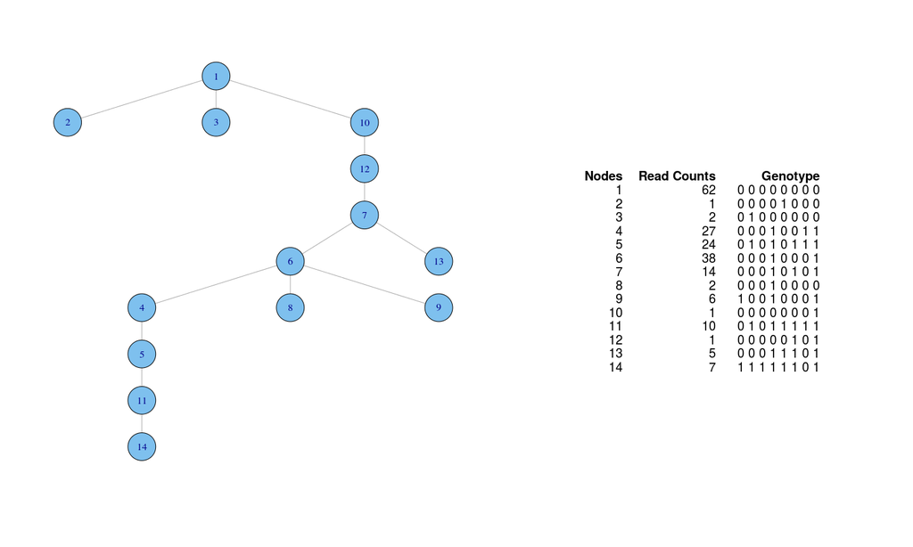

```r
mst <- get_mst(hc_genotype)
plot_mst(hc_genotype, hc_label, mst, flag=F)
```

# 2 Reproducing V-measures in Figure 3

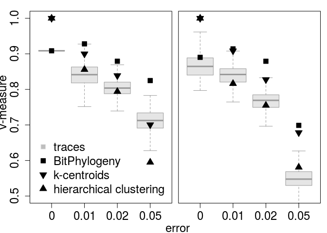

```r
data(saved_vmeasures)

mcmc_vmeasures <- saved_vmeasures$mcmc_vmeasures
hc_vmeasures <- saved_vmeasures$hc_vmeasures
kc_vmeasures <- saved_vmeasures$kc_vmeasures
mpear_vmeasures <- saved_vmeasures$mpear_vmeasures

par(mfrow=c(1,2), oma = c(3,3,0,0) + 0.1,
    mar = c(0,0,1,0.5) + 0.1, cex.lab=1.5, cex.axis=1.5)
boxplot(mcmc_vmeasures$big_clone, outline=F,
        ylim=c(0.5,1) ,
        cex.main=1.3,
        border=c('gray60'), col='gray90')
points( mpear_vmeasures$big_clone, pch=22,cex = 1.5, bg= 'black')
points( hc_vmeasures$big_clone, pch=24,cex = 1.5, bg= 'black')
points( kc_vmeasures$big_clone, pch=25,cex = 1.5, bg= 'black')

boxplot(mcmc_vmeasures$small_clone, outline=F,
        ylim=c(0.5,1) ,
        yaxt='n',cex.main=1.3,
        border=c('gray60'), col='gray90')
points( mpear_vmeasures$small_clone, pch=22, cex = 1.5, bg= 'black')
points( hc_vmeasures$small_clone, pch=24, cex=1.5, bg= 'black')
points( kc_vmeasures$small_clone, pch=25, cex = 1.5, bg= 'black')
colors1 <- c("gray90",'black', 'black', "black")
colors2 <- c("gray",'black', 'black', "black")
add_legend("bottomleft", legend=c("traces", 'BitPhylogeny',
                                  'k-centroids',
                                  'hierarchical clustering'),
           pch=c(22,22,25,24), inset = c(0.1,0.13), col=colors1,
           pt.bg=colors2,
           horiz=F, bty='n', cex=1.5)
title(xlab = "error",
      ylab = "v-measure",
      outer = TRUE, line = 2.2)
```

# 3 Reproducing number of nodes and maximum tree depth plots in Figure 3

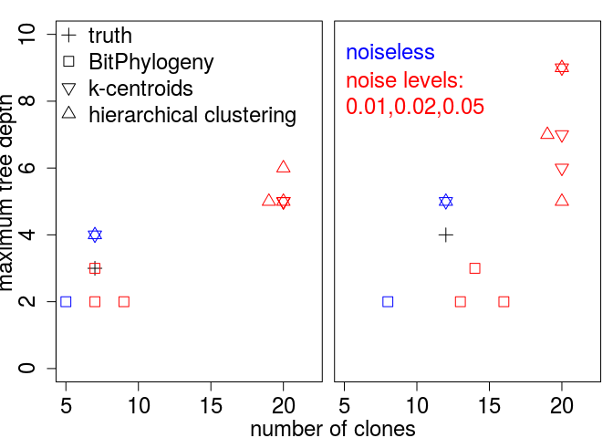

```r
big_clone_t <- c(3, 7)
big_clone_bit <- c(2, 5)
big_clone_hc <- c(4, 7)
big_clone_kc <- c(4, 7)
big_clone_bit <- rbind(big_clone_bit,
                      c(3, 7), c(2,9 ), c(2,7) )
big_clone_hc <- rbind(big_clone_hc,
                     c(5, 19), c(5,20), c(6,20))
big_clone_kc <- rbind(big_clone_kc,
                     c(5, 20), c(5, 20), c(5,20))

small_clone_t <- c(4, 12)
small_clone_bit <- c(2, 8)
small_clone_hc <- c(5, 12)
small_clone_kc <- c(5, 12)

small_clone_bit <- rbind(small_clone_bit,
                        c(3, 14),c(2,16 ), c(2,13) )
small_clone_hc <- rbind(small_clone_hc,
                       c(7, 19),c(5,20), c(9,20))
small_clone_kc <- rbind(small_clone_kc,
                       c(9, 20),c(7, 20), c(6,20))

par(mfrow=c(1,2), oma = c(3,3,0,0) + 0.1,
    mar = c(0,0,1,0.5) + 0.1, cex.lab=1.5, cex.axis=1.5)
color <- c('blue', 'red', 'red', 'red')
plot(big_clone_t[2], big_clone_t[1],pch=3, ylim=c(0,10) ,xlim= c(5,22)
     ,cex=1.5)
points(big_clone_bit[,2], big_clone_bit[,1],pch=0,cex=1.5, col=color)
points(big_clone_hc[,2], big_clone_hc[,1],pch=2,cex=1.5, col=color)
points(big_clone_kc[,2], big_clone_kc[,1],pch=6,cex=1.5, col=color)

plot(small_clone_t[2], small_clone_t[1], pch=3, ylim=c(0,10),
     xlim= c(5,22), cex=1.5, yaxt='n')
points(small_clone_bit[,2], small_clone_bit[,1], pch=0, cex=1.5, col=color)
points(small_clone_hc[,2], small_clone_hc[,1], pch=2, cex=1.5, col=color)
points(small_clone_kc[,2], small_clone_kc[,1], pch=6, cex=1.5, col=color)

colors1 <- c("black",'black', 'black', "black")
colors2 <- c("black",'black', 'black', "black")
add_legend("topleft", legend=c("truth", 'BitPhylogeny',
                                  'k-centroids',
                                  'hierarchical clustering'),
           pch=c(3,0,6,2), inset = c(0.08,0.02), col=colors1,
           pt.bg=colors2,
           horiz=F, bty='n', cex=1.5)
add_legend("topleft", legend=c("noiseless", 'noise levels: \n0.01,0.02,0.05'),
           inset = c(0.50,0.02), text.col=c('blue','red'),
           horiz=F, bty='n', cex=1.5)
title(xlab = "number of clones",
      ylab = "maximum tree depth",
      outer = TRUE, line = 2.2)
```

# 4 Reproducing tree distance in Figure 4

```
## ymax not defined: adjusting position using y instead
```

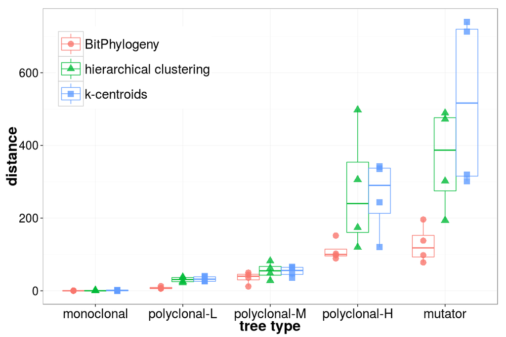

```r
library(ggplot2)
library(plyr)
library(grid)


metrics1 <- get_common_tree_distance_df("/media/nas/BitPhylogeny//methylation/mono_tree_simulations",
                                        "/media/nas/BitPhylogeny//methylation/mono_tree_baseline",
                                        "/media/nas/BitPhylogeny//methylation/mono_tree_baseline",
                                        "mono-clone",
                                        "/media/nas/BitPhylogeny//methylation/tree-truth-full-mono-methy.gdl")

metrics2 <- get_common_tree_distance_df("/media/nas/BitPhylogeny//methylation/big_tree_simulations",
                                        "/media/nas/BitPhylogeny//methylation/big_tree_baseline",
                                        "/media/nas/BitPhylogeny//methylation/big_tree_baseline",
                                        "big-clone",
                                        "/media/nas/BitPhylogeny//methylation/tree-truth-full-big-methy.gdl")

metrics3 <- get_common_tree_distance_df("/media/nas/BitPhylogeny//methylation/small_tree_simulations",
                                        "/media/nas/BitPhylogeny//methylation/small_tree_baseline",
                                        "/media/nas/BitPhylogeny//methylation/small_tree_baseline",
                                        "small-clone",
                                        "/media/nas/BitPhylogeny//methylation/tree-truth-full-small-methy.gdl")

metrics4 <- get_common_tree_distance_df("/media/nas/BitPhylogeny//methylation/hyper_tree_simulations",
                                        "/media/nas/BitPhylogeny//methylation/hyper_tree_baseline",
                                        "/media/nas/BitPhylogeny//methylation/hyper_tree_baseline",
                                        "hyper-clone",
                                        "/media/nas/BitPhylogeny//methylation/tree-truth-full-hyper-methy.gdl")


metrics5 <- get_common_tree_distance_df("/media/nas/BitPhylogeny//methylation/star_tree_simulations",
                                        "/media/nas/BitPhylogeny//methylation/star_tree_baseline",
                                        "/media/nas/BitPhylogeny//methylation/star_tree_baseline",
                                        "star-clone",
                                        "/media/nas/BitPhylogeny//methylation/tree-truth-full-star-methy.gdl")

metrics <- rbind(metrics1, metrics2, metrics3, metrics4, metrics5)
levels(metrics$tree_type) <- c("monoclonal",
                               "polyclonal-L",
                               "polyclonal-M",
                               "polyclonal-H",
                               "mutator")
levels(metrics1$tree_type) <- c("monoclonal",
                                "polyclonal-L",
                                "polyclonal-M",
                                "polyclonal-H",
                                "mutator")

print(ggplot(data = metrics, aes(x = tree_type, y = distance,  color = method,
                                 shape = method)) +
        geom_jitter( position = position_dodge(width = 0.75), alpha = 0.8,
                     size = 5 ) + geom_boxplot(fill = NA, outlier.colour = NA) +
        theme_bw() + xlab("tree type") +
        theme(axis.title.x = element_text(face="bold", size=25),
              axis.text.x  = element_text(vjust=0.5, size=22, angle = 0),
              axis.title.y = element_text(face="bold", size=25),
              axis.text.y  = element_text(size=20),
              legend.title = element_blank(),
              legend.text = element_text(size = 22),
              legend.position = c(0.2,0.8),
              legend.key.size = unit(1.5, "cm")))
```

```
## ymax not defined: adjusting position using y instead
```

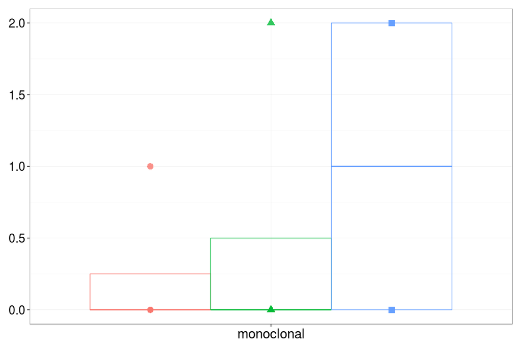

```r
print(ggplot(data = metrics1, aes(x = tree_type, y = distance,  color = method,
                                  shape = method)) +
        geom_jitter( position = position_dodge(width = 0.75), alpha = 0.8,
                     size = 5) + geom_boxplot(fill = NA, outlier.colour = NA) +
        theme_bw() +  xlab("tree type") +
      theme(axis.title.x = element_blank(),
            axis.title.y = element_blank(),
            axis.text.x  = element_text(vjust=0.5, size=22),
            axis.text.y  = element_text(size=20),
            legend.position = "none"))
```

# 5 Reproducing Figure 5

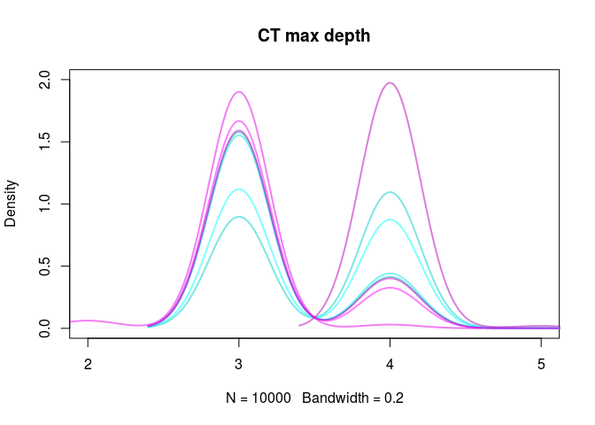

```r
CT_R1<-read.table("/media/nas/BitPhylogeny/methylation/backup/final_mcmcrun_incomplete_2//Sottoriva/final/incorrespondent-6142/CT_IRX2P_R1.csv/traces-CT_IRX2P_R1.csv",sep=",",header=T)
CT_R4<-read.table("/media/nas/BitPhylogeny/methylation/backup/final_mcmcrun_incomplete_2//Sottoriva/final/scolia-5868/CT_IRX2P_R4.csv/traces-CT_IRX2P_R4.csv",sep=",",header=T)
CT_R5<-read.table("/media/nas/BitPhylogeny/methylation/backup/final_mcmcrun_incomplete_2//Sottoriva/final/neuromerous-9376/CT_IRX2P_R5.csv/traces-CT_IRX2P_R5.csv",sep=",",header=T)
CT_R6<-read.table("/media/nas/BitPhylogeny/methylation/backup/final_mcmcrun_incomplete_2//Sottoriva/final/proaccelerin-3347/CT_IRX2P_R6.csv/traces-CT_IRX2P_R6.csv",sep=",",header=T)

CT_L2<-read.table("/media/nas/BitPhylogeny/methylation/backup/final_mcmcrun_incomplete_2//Sottoriva/final/oceanity-4938/CT_IRX2P_L2.csv/traces-CT_IRX2P_L2.csv",sep=",",header=T)
CT_L3<-read.table("/media/nas/BitPhylogeny/methylation/backup/final_mcmcrun_incomplete_2//Sottoriva/final/nonprolific-2900/CT_IRX2P_L3.csv/traces-CT_IRX2P_L3.csv",sep=",",header=T)
CT_L7<-read.table("/media/nas/BitPhylogeny/methylation/backup/final_mcmcrun_incomplete_2//Sottoriva/final/buoy-3083/CT_IRX2P_L7.csv/traces-CT_IRX2P_L7.csv",sep=",",header=T)
CT_L8<-read.table("/media/nas/BitPhylogeny/methylation/backup/final_mcmcrun_incomplete_2//Sottoriva/final/epistyle-3189/CT_IRX2P_L8.csv/traces-CT_IRX2P_L8.csv",sep=",",header=T)

feature<-5
band<-0.2
g<-density(CT_R1[,feature],bw=band)

plot(g, col=rgb(0,0.7,0.7,1/2), main="CT max depth", xlim=c(min(CT_R1[,feature],CT_R4[,feature],CT_R5[,feature],CT_R6[,feature],CT_L2[,feature],CT_L3[,feature],CT_L7[,feature],CT_L8[,feature]),max(CT_R1[,feature],CT_R4[,feature],CT_R5[,feature],CT_R6[,feature],CT_L2[,feature],CT_L3[,feature],CT_L7[,feature],CT_L8[,feature])),
        ylim=c(0,2),lwd=2, xaxt='n')
axis(1, at=c(2,3,4,5), labels=c(2,3,4,5))
lines(density(CT_R4[,feature],bw=band), col=rgb(0,0.8,0.8,1/2),lwd=2)
lines(density(CT_R5[,feature],bw=band), col=rgb(0,0.9,0.9,1/2),lwd=2)
lines(density(CT_R6[,feature],bw=band), col=rgb(0,1,1,1/2),lwd=2)

lines(density(CT_L2[,feature],bw=band), col=rgb(0.7,0,0.7,1/2),lwd=2)
lines(density(CT_L3[,feature],bw=band), col=rgb(0.8,0,0.8,1/2),lwd=2)
lines(density(CT_L7[,feature],bw=band), col=rgb(0.9,0,0.9,1/2),lwd=2)
lines(density(CT_L8[,feature],bw=band), col=rgb(1,0,1,1/2),lwd=2)
```

```r
wilcox.test(c(var(CT_R1[,feature]), var(CT_R4[,feature]), var(CT_R5[,feature]), var(CT_R6[,feature])),c(var(CT_L2[,feature]),var(CT_L3[,feature]),var(CT_L7[,feature]),var(CT_L8[,feature])),
    alternative="greater")
```

```
##
##  Wilcoxon rank sum test
##
## data:  c(var(CT_R1[, feature]), var(CT_R4[, feature]), var(CT_R5[, feature]),  and c(var(CT_L2[, feature]), var(CT_L3[, feature]), var(CT_L7[, feature]),     var(CT_R6[, feature])) and     var(CT_L8[, feature]))
## W = 16, p-value = 0.01429
## alternative hypothesis: true location shift is greater than 0
```

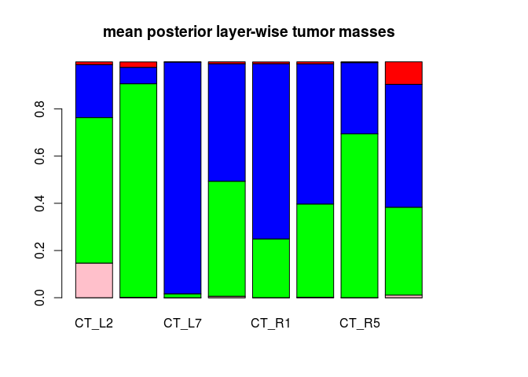

```r
feature<-23

massesR<-matrix(c(mean(CT_R1[,feature]),mean(CT_R1[,feature+1]),mean(CT_R1[,feature+2]),mean(CT_R1[,feature+3]),mean(CT_R1[,feature+4]),mean(CT_R4[,feature]),mean(CT_R4[,feature+1]),mean(CT_R4[,feature+2]),mean(CT_R4[,feature+3]),mean(CT_R4[,feature+4]),
        mean(CT_R5[,feature]),mean(CT_R5[,feature+1]),mean(CT_R5[,feature+2]),mean(CT_R5[,feature+3]),mean(CT_R5[,feature+4]),mean(CT_R6[,feature]),mean(CT_R6[,feature+1]),mean(CT_R6[,feature+2]),mean(CT_R6[,feature+3]),mean(CT_R6[,feature+4])),nrow=5)
massesL<-matrix(c(mean(CT_L2[,feature]),mean(CT_L2[,feature+1]),mean(CT_L2[,feature+2]),mean(CT_L2[,feature+3]),mean(CT_L2[,feature+4]),mean(CT_L3[,feature]),mean(CT_L3[,feature+1]),mean(CT_L3[,feature+2]),mean(CT_L3[,feature+3]),mean(CT_L3[,feature+4]),
                mean(CT_L7[,feature]),mean(CT_L7[,feature+1]),mean(CT_L7[,feature+2]),mean(CT_L7[,feature+3]),mean(CT_L7[,feature+4]),mean(CT_L8[,feature]),mean(CT_L8[,feature+1]),mean(CT_L8[,feature+2]),mean(CT_L8[,feature+3]),mean(CT_L8[,feature+4])),nrow=5)
masses<-cbind(massesL,massesR)
masses<-apply(masses,2,rev)
par(mar=c(5.1,4.1,4.1,6.1))
barplot(masses,col=rev(c("red","blue","green","pink","orange")),names.arg=c("CT_L2", "CT_L3", "CT_L7", "CT_L8", "CT_R1", "CT_R4", "CT_R5", "CT_R6"),main="mean posterior layer-wise tumor masses",
        args.legend = list(x=11.5, y=1), bty = "n")
```

```r
x<-0
massesR<-massesR+0.00000001
massesL<-massesL+0.00000001
rightDiff<-rep(0,6)
leftDiff<-rep(0,6)
for (j in 1:3 ) {
    for (i in (j+1):4) {
        x<-x+1
            rightDiff[x]<-(sum(log(massesR[,j]/massesR[,i])*massesR[,j])+sum(log(massesR[,i]/massesR[,j])*massesR[,i]))/2
            leftDiff[x]<-(sum(log(massesL[,j]/massesL[,i])*massesL[,j])+sum(log(massesL[,i]/massesL[,j])*massesL[,i]))/2
        }
}
wilcox.test(rightDiff,leftDiff,alternative='less')
```

```
##
##  Wilcoxon rank sum test
##
## data:  rightDiff and leftDiff
## W = 1, p-value = 0.002165
## alternative hypothesis: true location shift is less than 0
```

# 6 Reproducing Figure 6

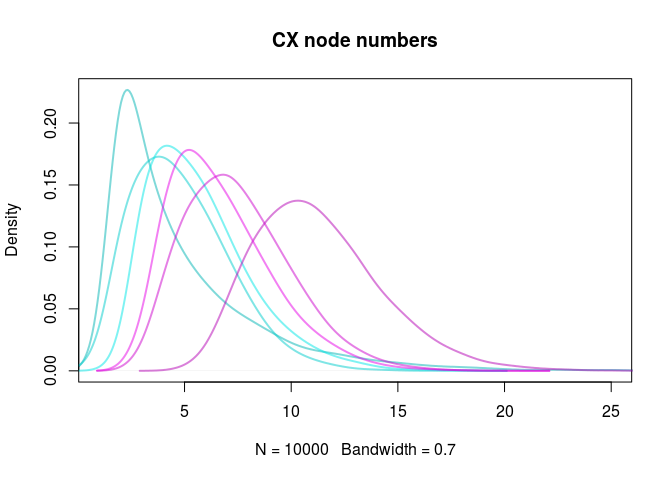

```r
CX_R1<-read.table("/media/nas/BitPhylogeny/methylation/backup/final_mcmcrun_incomplete_2//Sottoriva/final/demirelief-3049/CX_IRX2P_R1.csv/traces-CX_IRX2P_R1.csv",sep=",",header=T)
CX_R2<-read.table("/media/nas/BitPhylogeny/methylation/backup/final_mcmcrun_incomplete_2//Sottoriva/final/spatulose-3680/CX_IRX2P_R2.csv/traces-CX_IRX2P_R2.csv",sep=",",header=T)
CX_R6<-read.table("/media/nas/BitPhylogeny/methylation/backup/final_mcmcrun_incomplete_2//Sottoriva/final/alevin-293/CX_IRX2P_R6.csv/traces-CX_IRX2P_R6.csv",sep=",",header=T)

CX_L3<-read.table("/media/nas/BitPhylogeny/methylation/backup/final_mcmcrun_incomplete_2/Sottoriva/final/uplinked-8718/CX_IRX2P_L3.csv/traces-CX_IRX2P_L3.csv",sep=",",header=T)
CX_L4<-read.table("/media/nas/BitPhylogeny/methylation/backup/final_mcmcrun_incomplete_2/Sottoriva/final/subtransverse-8545/CX_IRX2P_L4.csv/traces-CX_IRX2P_L4.csv",sep=",",header=T)
CX_L5<-read.table("/media/nas/BitPhylogeny/methylation/backup/final_mcmcrun_incomplete_2/Sottoriva/final/marbleness-8646/CX_IRX2P_L5.csv/traces-CX_IRX2P_L5.csv",sep=",",header=T)


# #par(mfrow=c(1,2))
feature<-2
band<-0.7
g<-density(CX_R1[,feature],bw=band)

plot(g, col=rgb(0,0.7,0.7,1/2), lwd=2, main="CX node numbers", xlim=c(min(CX_R1[,feature],CX_R2[,feature],CX_L3[,feature],CX_L4[,feature],CX_L5[,feature]),25))
lines(density(CX_R2[,feature],bw=band), col=rgb(0,0.8,0.8,1/2),lwd=2)
lines(density(CX_R6[,feature],bw=band), col=rgb(0,0.9,0.9,1/2),lwd=2)

lines(density(CX_L3[,feature],bw=band), col=rgb(0.7,0,0.7,1/2),lwd=2)
lines(density(CX_L4[,feature],bw=band), col=rgb(0.8,0,0.8,1/2),lwd=2)
lines(density(CX_L5[,feature],bw=band), col=rgb(0.9,0,0.9,1/2),lwd=2)
```

```r
#
#
 t.test(c(mean(CX_R1[,feature]),mean(CX_R2[,feature]),mean(CX_R6[,feature])),c(mean(CX_L3[,feature]),mean(CX_L4[,feature]),mean(CX_L5[,feature])))
```

```
##
##  Welch Two Sample t-test
##
## data:  c(mean(CX_R1[, feature]), mean(CX_R2[, feature]), mean(CX_R6[,  and c(mean(CX_L3[, feature]), mean(CX_L4[, feature]), mean(CX_L5[,     feature])) and     feature]))
## t = -2.347, df = 2.173, p-value = 0.1334
## alternative hypothesis: true difference in means is not equal to 0
## 95 percent confidence interval:
##  -9.070  2.352
## sample estimates:
## mean of x mean of y
##     5.124     8.483
```

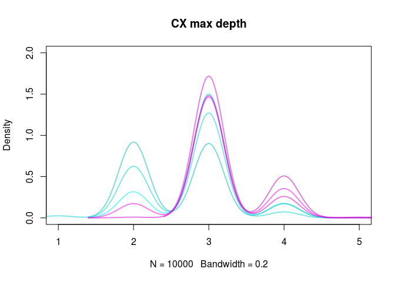

```r
#
feature<-5
band<-0.2
g<-density(CX_R1[,feature],bw=band)

plot(g, col=rgb(0,0.7,0.7,1/2), main="CX max depth", xlim=c(min(CX_R1[,feature],CX_R2[,feature],CX_L3[,feature],CX_L4[,feature],CX_L5[,feature]),max(CX_R1[,feature],CX_R2[,feature],CX_L3[,feature],CX_L4[,feature],CX_L5[,feature])),
        ylim=c(0,2),lwd=2, xaxt='n')
axis(1, at=c(1,2,3,4,5), labels=c(1,2,3,4,5))
lines(density(CX_R2[,feature],bw=band), col=rgb(0,0.8,0.8,1/2),lwd=2)
lines(density(CX_R6[,feature],bw=band), col=rgb(0,0.9,0.9,1/2),lwd=2)

lines(density(CX_L3[,feature],bw=band), col=rgb(0.7,0,0.7,1/2),lwd=2)
lines(density(CX_L4[,feature],bw=band), col=rgb(0.8,0,0.8,1/2),lwd=2)
lines(density(CX_L5[,feature],bw=band), col=rgb(0.9,0,0.9,1/2),lwd=2)
```

```r
#
t.test(c(mean(CX_R1[,feature]),mean(CX_R2[,feature]),mean(CX_R6[,feature])),c(mean(CX_L3[,feature]),mean(CX_L4[,feature]),mean(CX_L5[,feature])))
```

```
##
##  Welch Two Sample t-test
##
## data:  c(mean(CX_R1[, feature]), mean(CX_R2[, feature]), mean(CX_R6[,  and c(mean(CX_L3[, feature]), mean(CX_L4[, feature]), mean(CX_L5[,     feature])) and     feature]))
## t = -3.959, df = 3.099, p-value = 0.02711
## alternative hypothesis: true difference in means is not equal to 0
## 95 percent confidence interval:
##  -0.73421 -0.08632
## sample estimates:
## mean of x mean of y
##     2.751     3.161
```

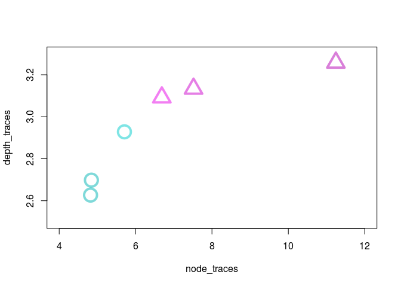

```r
#
#
#


feature1<-2
feature2<-5
plot(mean(CX_R1[,feature1]),mean(CX_R1[,feature2]),xlim=c(4,12),ylim=c(2.5,3.3),col=rgb(0,0.7,0.7,1/2),lwd=4, cex=3, ylab=colnames(CX_R1)[feature2],xlab=colnames(CX_R1)[feature1])
points(mean(CX_R2[,feature1]),mean(CX_R2[,feature2]),col=rgb(0,0.7,0.7,1/2),lwd=4,cex=3)
points(mean(CX_R6[,feature1]),mean(CX_R6[,feature2]),col=rgb(0,0.8,0.8,1/2),lwd=4,cex=3)

points(mean(CX_L3[,feature1]),mean(CX_L3[,feature2]),col=rgb(0.7,0,0.7,1/2),lwd=4,pch=2,cex=3)
points(mean(CX_L4[,feature1]),mean(CX_L4[,feature2]),col=rgb(0.8,0,0.8,1/2),lwd=4,pch=2,cex=3)
points(mean(CX_L5[,feature1]),mean(CX_L5[,feature2]),col=rgb(0.9,0,0.9,1/2),lwd=4,pch=2,cex=3)
```

# 7 Reproducing Figure 7 and S3

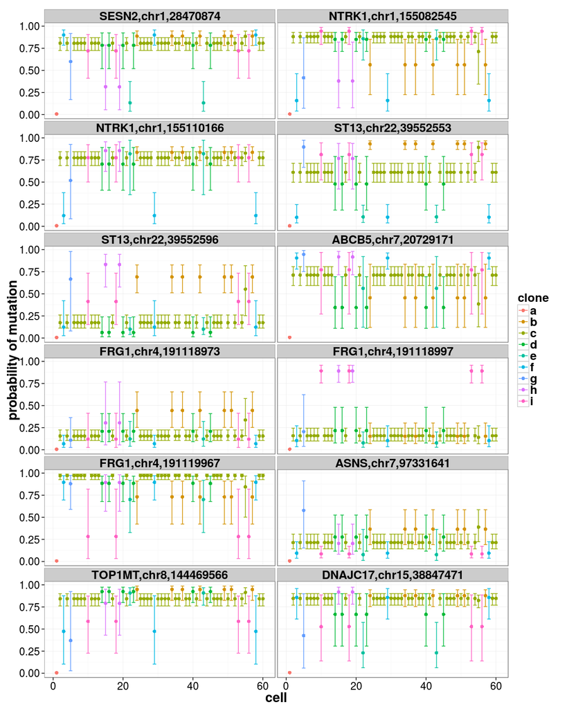

```r
library(e1071)
load("~/Dropbox/bitphylogeny_pkg/single_cell/params_summary.Rdata")

snv <- read.csv("~/Dropbox/bitphylogeny_pkg/single_cell/snv.csv", as.is = T)

cellNames <- colnames(snv)[-1]

geneList <- read.table("~/Dropbox/bitphylogeny_pkg/single_cell/Outfile_short.csv", header = T, as.is =T)

bed <- read.csv('~/Dropbox/bitphylogeny_pkg/single_cell/hou_data_bed.csv', as.is = T)

indexSESN2 <- geneList[which(geneList[,"GeneSym"] == "SESN2"),
                       c("Chrom", "Start", "GeneSym")]

indexNTRK1 <- geneList[which(geneList[,"GeneSym"] == "NTRK1"),
                       c("Chrom", "Start", "GeneSym")]

indexST13 <- geneList[which(geneList[,"GeneSym"] == "ST13"),
                      c("Chrom", "Start", "GeneSym")]

indexABCB5 <- geneList[which(geneList[,"GeneSym"] == "ABCB5"),
                       c("Chrom", "Start", "GeneSym")]

indexFRG1 <- geneList[which(geneList[,"GeneSym"] == "FRG1"),
                      c("Chrom", "Start", "GeneSym")]

indexASNS <- geneList[which(geneList[,"GeneSym"] == "ASNS"),
                      c("Chrom", "Start", "GeneSym")]

indexTOP1MT <- geneList[which(geneList[,"GeneSym"] == "TOP1MT"),
                        c("Chrom", "Start", "GeneSym")]

indexDNAJC17 <- geneList[which(geneList[,"GeneSym"] == "DNAJC17"),
                         c("Chrom", "Start", "GeneSym")]

indexDF <- rbind(indexSESN2, indexNTRK1, indexST13, indexABCB5, indexFRG1,
                 indexASNS, indexTOP1MT, indexDNAJC17)

rownames(indexDF) <- NULL

ll <- mapLabels[1,]
rownames(ll) <- NULL
colnames(ll) <- NULL

ll <- as.character(ll)
ll <- revalue(ll, c("0"="a", "2"="c", "10"="f", "11"="g", "5"="i",
              "7"="d", "4"="h", "8"="e", "1"="b"))


FindGeneIndex <- function(x, y){
  ind <- c()
  for (i in 1:dim(y)[1]) {
    tmp <- sapply(1:dim(x)[1], function(j) sum(x[j,] == y[i,]) == 2)
    ind <- c(ind, which(tmp == T))
  }
  return(ind)
}

GetGeneDataFrame <- function (bed, index, snv, ll, meanParams, sdParams) {
  x <- data.frame()
  for (i in 1 : dim(index)[1]) {

    ind <- FindGeneIndex(bed[, c(1,2)], index[i, c(1,2)])

    meanValues <- meanParams[ind, ]
    sdValues <- sdParams[ind, ]
    snvData <- t(snv[ind, -1])
    rownames(snvData) <- NULL
    colnames(snvData) <- NULL
    snvData[is.na(snvData)] <- 2

    x <- rbind(x,
               data.frame(mean= meanValues,
                          sd = sdValues,
                          cell = 1:60,
                          snv = as.factor(snvData),
                          clone = as.factor(t(ll)),
                          gene = paste(index[i, 3],
                                       index[i, 1],
                                       index[i, 2],
                                       sep = ",") ) )
  }
  return(x)
}

dfall <- GetGeneDataFrame(bed, indexDF, snv, ll, meanParams, sdParams)

print(ggplot(dfall, aes(x=cell, y=sigmoid(mean), color = clone)) +
  geom_errorbar(aes(ymin= sigmoid(mean-sd), ymax=sigmoid(mean+sd)), width=1) +
  geom_point(size=2.5) + ylab("probability of mutation") +
  facet_wrap(~gene, ncol=2) + theme_bw() +
  theme(axis.text.x  = element_text(vjust=0.5, size = 16),
        axis.title.x = element_text(face="bold", size = 20),
        axis.text.y = element_text(size = 16),
        axis.title.y = element_text(face="bold", size = 20),
        legend.title = element_text(face="bold",size = 18),
        legend.text = element_text(face="bold",size = 18),
        strip.text.x = element_text(face="bold",size = 18))
  )
```

# 8 Reproducing Figure S1

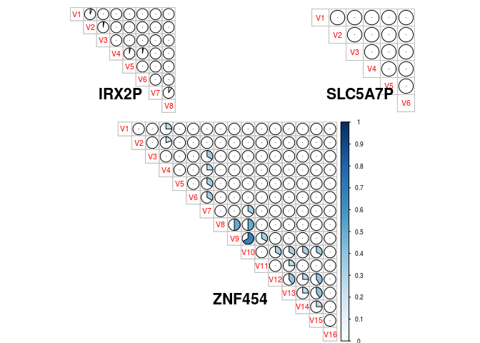

Precentage of significant correlation between loci of the three regions in Sottoriva et al.

```r
library(bitphylogenyR)
library(corrplot)
library(psych)
SetLociCorr <- function(mode = "IRX2P"){
  files <- dir(system.file('extdata/sottoriva/', package = "bitphylogenyR"),
               full.names = T, pattern = mode)
  if (mode == "IRX2P") {
    n = 8
  } else if (mode == "SLC5A7P") {
    n = 6
  } else {
    n = 16
  }

  corrmat <- array(0, dim = c(n, n))
  nonnacount <- array(0, dim = c(n, n))

  for (i in 1:length(files)) {
    x <- read.csv(files[i])
    t1 <- corr.test(unique(x), method = "kendall")
    t2 <- t1$p <= 0.05
    t2[which(is.na(t2))] <- FALSE
    corrmat <- corrmat + t2
    nonnacount <- nonnacount + !is.na(t1$p <= 0.05)
  }

  corrmat[lower.tri(corrmat)] <- 0
  corrmat <- corrmat + t(corrmat)
  diag(corrmat) = diag(corrmat) / 2
  M <- corrmat / nonnacount
  return( M )
}

M1 <- SetLociCorr(mode = "IRX2P")
M2 <- SetLociCorr(mode = "SLC5A7P")
M3 <- SetLociCorr(mode = "ZNF454")

mat <- matrix(c(1,3,3,2,3,3), 3)

layout(mat)
corrplot(M1, method = "pie", is.corr=F,
         cl.lim = c(0,1), type = "upper", tl.pos = "d", cl.pos = "n")
title("IRX2P", line = -11, cex.main = 2)
corrplot(M2, method = "pie", is.corr=F,
         cl.lim = c(0,1), type = "upper", tl.pos = "d", cl.pos = "n")
title("SLC5A7P",  line = -11, cex.main = 2)
corrplot(M3, method = "pie", is.corr=F,
         cl.lim = c(0,1), type = "upper", tl.pos = "d")
title("ZNF454",  line = -21, cex.main = 2)
```